# DATA VISUALIZATION WITH PYTHON

## SECTION 1. INTRODUCTION

Data visualization plays a role in unlocking insights from datasets making complex information more understandable and aiding informed decision making in the field of data science. Through representations of data we can easily identify patterns, trends and outliers which leads to an understanding of the underlying information. Python has emerged as a programming language in the realm of data visualization primarily because it offers a range of libraries specifically designed for this purpose.

### The Importance of Data Visualization.

In the world of data science, where dealing with intricate datasets is commonplace the significance of data visualization cannot be overstated. It acts as a link between data and human comprehension enabling analysts, scientists and decision makers to extract meaningful insights efficiently. A crafted visualization not conveys information quickly but also has the power to reveal hidden patterns that may be difficult to discern when presented in tables or text formats.

### Pythons Popularity in Data Visualization

Python has become the language for data scientists and analysts due to its simplicity, versatility and robust ecosystem of libraries specifically tailored for data visualization purposes. These libraries offer tools for creating dynamic and interactive visualizations that cater to diverse needs, within the data science community.

### Python Libraries for Visualizing Data

Matplotlib; Matplotlib is a library, in the Python data science ecosystem. It offers an array of options for creating visualizations quickly.

Seaborn; Built on top of Matplotlib, Seaborn focuses on visualizing data. It simplifies the process of creating informative and visually appealing graphics.

Plotly; Plotly is renowned for its web based visualizations making it an excellent choice when you need exploratory plots.

Bokeh; Bokeh shines in creating expressive visualizations making it particularly valuable for web based applications.

The popularity of Python among the data science community can be attributed to how these libraries integrate with one another allowing users to choose the one that best suits their visualization needs. In the following sections we will explore these Python libraries. Showcase their usage through examples to highlight how Pythons data visualization capabilities provide a toolkit, for exploring and conveying insights regardless of whether you are a beginner or an experienced data scientist.

## SECTION 2: PYTHON LIBRARIES FOR VISUALIZATION

Pythons strength in visualizing data lies in its range of libraries. In this section we will explore some of the players;

### 2.1 Matplotlib

Matplotlib holds a position in the landscape of Pythons data visualization capabilities. Its user friendly interface and adaptability make it an excellent starting point for creating types of plots. Whether its line plots, scatter plots, bar charts or complex visualizations Matplotlib can generate them effortlessly with a few lines of code. Lets take a look at an example that demonstrates how to create a line plot using Matplotlib;

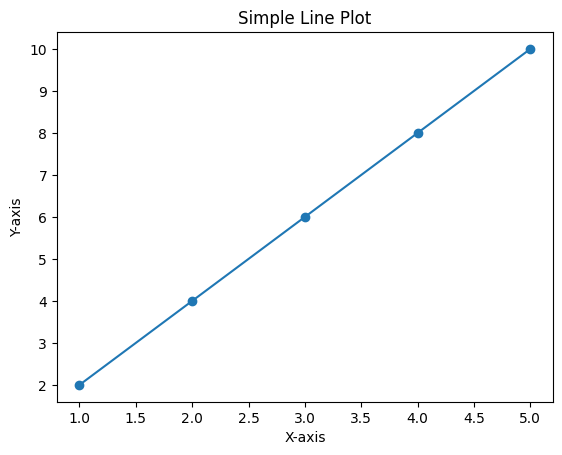

```python
import matplotlib.pyplot as plt

# Sample data
x = [1, 2, 3, 4, 5]
y = [2, 4, 6, 8, 10]

# Plotting the data
plt.plot(x, y, marker='o')
plt.title('Simple Line Plot')
plt.xlabel('X-axis')
plt.ylabel('Y-axis')
plt.show()
```

This straightforward syntax allows users to quickly visualize data, making Matplotlib an essential tool for data exploration and presentation.

### 2.2 Seaborn

Seaborn is an extension of Matplotlib that focuses on statistical data visualization. It aims to make the creation of informative and visually pleasing graphics easier. With its user interface Seaborn allows users to generate visualizations using concise code. Lets start by creating an example in Seaborn;

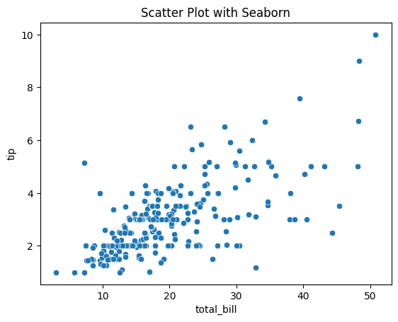

```python
import seaborn as sns
import matplotlib.pyplot as plt

# Sample data
tips = sns.load_dataset('tips')

# Creating a scatter plot with Seaborn
sns.scatterplot(x='total_bill', y='tip', data=tips)
plt.title('Scatter Plot with Seaborn')
plt.show()
```